# PRELIMINARY DATA: Redd Dewatering Estimates for Keswick Fall Flow Scenarios

BDO Science Division

03 September, 2024

This script constructs real-time winter-run redd dewatering estimates based on most recent data available from CDFW (August 28, 2024) for winter-run data and dewatering estimates from USFWS (2006; see citation). Data are also available in 2024 Winter-run Data file.xls online at calfish.org.

Please note that all data are preliminary until data collection is finalized. Likewise, there are uncertainties with forecasts which may lead to changes in proposed operations.

# Current Winter-run Chinook Salmon Redd Count

As of August 21, 2024, the unexpanded redd count is **147** Winter-run redds. It is important to note that until data collection is completed for the year these are the **minimum** number of possible redds. The Winter-run number will always expand upon final analysis but gives an in-season guard rail of the minimum number of redds this year.

Given that the number of Winter-run redds is always larger than the early season carcass counts, an expansion number based on historic data is multiplied by the carcass count to estimate the total number of redds for the season before the end of the season’s final estimate is developed and the final redd count is known. These additional estimates of redd counts (shown in Table 1) help to inform decisions regarding possible redd dewatering. However, expansion estimates have not been developed yet for the 2024 season and those in Table 1 are from the 2023 season.

Estimated total number of Winter-run redds and resulting number of redds that represent 1% of the population. Estimated total redds are based on current count and expansion numbers representing 1) average 2005-2022 expansion, 2) year-specific expansion determined by the linear relationship between yearly expansions vs recapture rate of tagged female salmon, 3) maximum 2005-2022 expansion, and 4) minimum 2005-2022 expansion.

| Name | Expansion Number | Total Redds | 1% |
| --- | --- | --- | --- |
| Current Count | 1.00 | 147 | 1.47 |
| Expected 2024 Expansion | 2.00 | 294 | 2.94 |
| Maximum Expansion | 3.45 | 507 | 5.07 |
| Minimum Expansion | 1.25 | 184 | 1.84 |

## Chinook Salmon Dewatered Redd Estimates

As of August 28, 2024, **1** Winter-run redds have **emerged** and **0** have been **dewatered**. This leaves **16** shallow water redds of concern.

There is no real time data on fall-run redd counts. Estimates are predicted based on estimated dewatering percentages from USFWS (2006) and spring-run and fall-run spawn timing based on fresh female carcasses encountered by week from 2003 through 2022. Emergence timing were predicted from average water temperatures over the same time period. Fall-run dewatered redd estimates range from **5.2** to **8.5%**. Note that fall-run dewatering estimates are likely overestimated using the dewatering percentages from USFWS (2006), and likely do not reflect actual dewatering percentages and should only be used for comparative purposes between scenarios. A comparative analysis between field and modeled dewatering percentages by Gosselin and Beer (2024) can be found here: https://www.cbr.washington.edu/sacramento/fishmodel/Note_on_Redd_Dewatering_Observed_v_Predicted.pdf.

Average September and October Keswick (KES) Flow in cfs, total water volume of each alternative for August through October and September through February in TAF, estimated numbers of SRWC redds dewatered, and percent of population that would be lost under each of the proposed alternatives. KES Flow data uses actual flow-to-date as of September 02, 2024 and proposed flows for the remainder of the incubation period. Redd dewatering is considered at the actual or estimated dewatering flow and with a 250 cfs buffer applied to the actual/estimated dewatering flow. Percentage of the population lost is based on the August 21, 2024 count of 147 Winter-run redds and updated redd counts may be available soon. See Scenario Descriptions file for additional information on each scenario.

[output not shown]

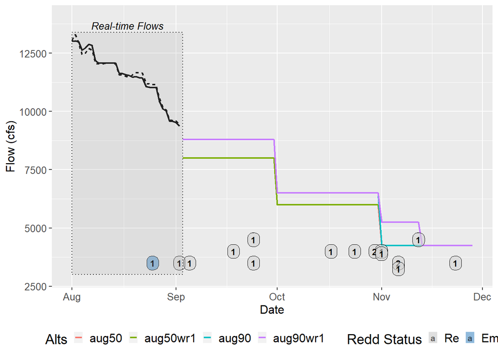

Actual or estimated emergence dates of SRWC redds and actual or estimated dewatering flow for the September-October estimated redd emergence dates as compared to Keswick flow (in cfs) of proposed management alternatives. Points represent dewatered (De), emerged (Em), or remaining (Re) redds. Numbers inside of points indicate how many redds share that estimated emergence date and actual/estimated dewatering flow. Points that fall above/to the right of a flow alternative line are expected to be dewatered given that management alternative is followed. Points that fall below/to the left of/on a flow alternative line are not expected to be dewatered, given that management alternative is followed. Shaded gray box shows period of real-time flow data; dashed black line equals KWK gauge flow and solid black line equals KES flow (from [SacPas](https://www.cbr.washington.edu/sacramento/data/query_river_table.html)).

Description of scenarios being considered and compared by the Upper Sacramento Scheduling Team.

| Scenario | Descripion |
| --- | --- |
| aug50 | Initial rough template scenario put together based on Aug 50% exceedance forecast. Strategy is to drop to baseflows as quickly as possible while meeting numerous downstream needs, reduce fall-run redd… |
| aug90 | Initial rough template scenario put together based on Aug 90% exceedance forecast. Strategy is to drop to baseflows as quickly as possible while meeting numerous downstream needs, reduce fall-run redd… |
| aug50wr1 | Draft scenario based off of August 50% forecast. Developed on 8-27-2024 to avoid any winter-run redd dewatering. |
| aug90wr1 | Draft scenario based off of August 90% forecast. Developed on 8-27-2024 to avoid any winter-run redd dewatering. |

# References

Gard, Mark. 2006. Relationships between flow fluctuations and redd dewatering and juvenile stranding for Chinook Salmon and Steelhead in the Sacramento River between Kesewick Dam and Battle Creek. 94 pages.

Gosselin, J.L. and W.N. Beer. 2024. Sacramento River Winter-run Chinook Salmon Redd Dewatering: a Note on Comparing Observed and Predicted. Central Valley Prediction and Assessment of Salmon (SacPas; https://www.cbr.washington.edu/sacramento/). Columbia Basin Research, School of Aquatic and Fishery Sciences, University of Washington.